# Airbnb Problem Definition

# Predictions where we were way off the mark

```python
# Extracting the rows from original data frame df where indexes are same as the training data
AirBnBdf_new = AirBnBdf_original[AirBnBdf_original.index.isin(x_train_sfs.index.values)].copy()

# Extracting predicted values and residuals from the final model
fitted_values = lin_reg_model_sfs.predict(x_train_sfs)
residuals = fitted_values - y_train

# # Add new columns for predicted values
AirBnBdf_new["Predicted_log_price "] = fitted_values
AirBnBdf_new["Predicted_Price"] = np.exp(fitted_values)
AirBnBdf_new["Price"] = np.exp(AirBnBdf_new.log_price)
AirBnBdf_new["residuals"] = residuals
AirBnBdf_new["Abs_residuals"] = np.exp(residuals)
# AirBnBdf_new["Difference_in_dollars"] = np.abs(AirBnBdf_new["Price"] - AirBnBdf_new["Predicted_Price"])
AirBnBdf_new["Difference_in_dollars"] = AirBnBdf_new["Price"] - AirBnBdf_new["Predicted_Price"]

# # Let us look at the top  predictions where our model made highest extimation errors (on train data)
AirBnBdf_new.sort_values(by=["Difference_in_dollars"], ascending=False).head(20)
```

|  | id | room_type | accommodates | bathrooms | cancellation_policy | cleaning_fee | instant_bookable | review_scores_rating | bedrooms | beds | log_price | Predicted_log_price | Predicted_Price | Price | residuals | Abs_residuals | Difference_in_dollars |
| --- | --- | --- | --- | --- | --- | --- | --- | --- | --- | --- | --- | --- | --- | --- | --- | --- | --- |
| 55453 | 14095274 | Entire home/apt | 7.0 | 3.5 | strict | True | t | 80.0 | 4.0 | 4.0 | 7.600402 | 4.372197 | 79.217520 | 1999.000001 | -1.735849 | 0.176251 | 1919.782481 |
| 54994 | 13751426 | Entire home/apt | 7.0 | 4.0 | flexible | True | f | NaN | 4.0 | 7.0 | 7.598399 | 4.400327 | 81.477476 | 1994.999999 | -1.633363 | 0.195272 | 1913.522524 |
| 61826 | 20230917 | Entire home/apt | 16.0 | 7.5 | strict | True | t | 98.0 | 7.0 | 16.0 | 7.598399 | 4.415074 | 82.687992 | 1994.999999 | -0.513583 | 0.598348 | 1912.312007 |
| 42672 | 16755372 | Entire home/apt | 2.0 | 1.0 | moderate | True | f | 85.0 | 1.0 | 1.0 | 7.600402 | 4.536213 | 93.336664 | 1999.000001 | -2.758684 | 0.063375 | 1905.663337 |
| 28420 | 20459710 | Entire home/apt | 5.0 | 3.5 | moderate | True | t | NaN | 2.0 | 2.0 | 7.598399 | 4.555318 | 95.137003 | 1994.999999 | -2.111981 | 0.120998 | 1899.862997 |
| 9390 | 16383008 | Private room | 2.0 | 1.0 | strict | False | f | NaN | 1.0 | 1.0 | 7.598399 | 4.676532 | 107.396955 | 1994.999999 | -3.120614 | 0.044130 | 1887.603045 |
| 24031 | 20001006 | Entire home/apt | 2.0 | 1.0 | flexible | False | f | NaN | 1.0 | 2.0 | 7.575585 | 4.192209 | 66.168772 | 1950.000001 | -2.662134 | 0.069799 | 1883.831229 |
| 3063 | 3962389 | Entire home/apt | 16.0 | 7.5 | strict | True | f | NaN | 8.0 | 11.0 | 7.598399 | 4.826051 | 124.717526 | 1994.999999 | -0.014140 | 0.985959 | 1870.282473 |
| 401 | 19839317 | Entire home/apt | 8.0 | 3.5 | strict | True | f | 100.0 | 3.0 | 3.0 | 7.569412 | 4.338723 | 76.609614 | 1937.999999 | -1.544255 | 0.213471 | 1861.390385 |
| 60071 | 11895042 | Entire home/apt | 6.0 | 1.0 | strict | False | f | NaN | 1.0 | 2.0 | 7.600402 | 4.940441 | 139.831856 | 1999.000001 | -2.438438 | 0.087297 | 1859.168145 |
| 21155 | 11974572 | Entire home/apt | 6.0 | 6.0 | flexible | True | f | NaN | 6.0 | 6.0 | 7.575585 | 4.577246 | 97.246222 | 1950.000001 | -1.080797 | 0.339325 | 1852.753778 |
| 49711 | 17368753 | Entire home/apt | 14.0 | 8.0 | strict | True | f | 80.0 | 6.0 | 10.0 | 7.575585 | 4.593269 | 98.816976 | 1950.000001 | -0.487612 | 0.614091 | 1851.183025 |
| 20722 | 7397916 | Entire home/apt | 16.0 | 5.5 | strict | False | f | NaN | 5.0 | 10.0 | 7.598399 | 5.073360 | 159.710096 | 1994.999999 | -0.748421 | 0.473113 | 1835.289904 |
| 72609 | 17943829 | Entire home/apt | 6.0 | 2.5 | flexible | False | t | NaN | 3.0 | 3.0 | 7.600402 | 5.128065 | 168.690335 | 1999.000001 | -1.939884 | 0.143721 | 1830.309666 |
| 19210 | 1240935 | Entire home/apt | 10.0 | 4.5 | strict | True | f | NaN | 4.0 | 4.0 | 7.600402 | 5.302955 | 200.929762 | 1999.000001 | -1.189438 | 0.304392 | 1798.070239 |
| 61435 | 4396985 | Entire home/apt | 5.0 | 3.0 | flexible | False | f | NaN | 3.0 | 2.0 | 7.549609 | 4.883971 | 132.154376 | 1900.000000 | -1.791809 | 0.166658 | 1767.845624 |
| 12106 | 52713 | Entire home/apt | 8.0 | 4.0 | moderate | True | f | NaN | 4.0 | 4.0 | 7.549609 | 4.900245 | 134.322655 | 1900.000000 | -1.419342 | 0.241873 | 1765.677345 |
| 20855 | 14959195 | Entire home/apt | 2.0 | 1.0 | flexible | False | f | NaN | 0.0 | 1.0 | 7.522941 | 4.520185 | 91.852624 | 1850.000000 | -2.541467 | 0.078751 | 1758.147376 |
| 68731 | 14188141 | Private room | 8.0 | 4.5 | moderate | True | t | NaN | 4.0 | 5.0 | 7.522941 | 4.678186 | 107.574708 | 1850.000000 | -1.978805 | 0.138234 | 1742.425291 |
| 7168 | 815879 | Entire home/apt | 14.0 | 6.5 | flexible | True | f | 100.0 | 6.0 | 6.0 | 7.506592 | 4.405796 | 81.924337 | 1820.000000 | -0.267772 | 0.765082 | 1738.075663 |

- Above result shows the cases where the Predicted price is way lesser than the actual price, most of them are in the Luxury accomodation category and a few of them belong to the accomodation type Private room. Predictions denote that this data may not be correct.

```python
AirBnBdf_new[(AirBnBdf_new.Difference_in_dollars > 250)]
```

|  | id | room_type | accommodates | bathrooms | cancellation_policy | cleaning_fee | instant_bookable | review_scores_rating | bedrooms | beds | log_price | Predicted_log_price | Predicted_Price | Price | residuals | Abs_residuals | Difference_in_dollars |
| --- | --- | --- | --- | --- | --- | --- | --- | --- | --- | --- | --- | --- | --- | --- | --- | --- | --- |
| 52 | 3530517 | Entire home/apt | 6.0 | 2.0 | flexible | True | t | 97.0 | 3.0 | 3.0 | 6.620073 | 5.866338 | 352.954132 | 750.0 | -1.033324 | 0.355822 | 397.045868 |
| 62 | 11712092 | Entire home/apt | 9.0 | 2.5 | flexible | False | f | NaN | 4.0 | 4.0 | 6.907755 | 5.432543 | 228.730107 | 1000.0 | -0.817721 | 0.441436 | 771.269893 |
| 63 | 20918988 | Private room | 2.0 | 1.5 | flexible | False | f | NaN | 1.0 | 1.0 | 6.214608 | 4.499636 | 89.984404 | 500.0 | -1.662721 | 0.189622 | 410.015596 |
| 80 | 16221430 | Entire home/apt | 3.0 | 1.0 | flexible | True | f | 100.0 | 1.0 | 1.0 | 5.857933 | 4.509222 | 90.851154 | 350.0 | -1.270056 | 0.280816 | 259.148846 |
| 104 | 14900814 | Entire home/apt | 9.0 | 3.0 | moderate | True | t | 96.0 | 4.0 | 4.0 | 6.171701 | 4.492338 | 89.330024 | 479.0 | -0.167619 | 0.845676 | 389.669976 |
| ... | ... | ... | ... | ... | ... | ... | ... | ... | ... | ... | ... | ... | ... | ... | ... | ... | ... |
| 74031 | 189787 | Entire home/apt | 8.0 | 5.0 | strict | True | f | 100.0 | 5.0 | 5.0 | 6.907755 | 5.009215 | 149.787099 | 1000.0 | -0.463637 | 0.628992 | 850.212901 |
| 74051 | 8501722 | Entire home/apt | 4.0 | 2.0 | strict | False | t | 100.0 | 1.0 | 2.0 | 6.013715 | 5.059327 | 157.484519 | 409.0 | -0.874540 | 0.417054 | 251.515481 |
| 74079 | 15898650 | Entire home/apt | 4.0 | 1.0 | moderate | True | f | 99.0 | 2.0 | 2.0 | 5.978886 | 4.486587 | 88.817773 | 395.0 | -0.767869 | 0.464001 | 306.182227 |
| 74081 | 13996915 | Entire home/apt | 16.0 | 1.0 | moderate | False | t | NaN | 1.0 | 1.0 | 6.907755 | 4.913450 | 136.108202 | 1000.0 | -0.916084 | 0.400083 | 863.891798 |
| 74084 | 10387373 | Entire home/apt | 4.0 | 1.0 | strict | False | f | 100.0 | 2.0 | 3.0 | 5.843544 | 4.428884 | 83.837766 | 345.0 | -0.614034 | 0.541163 | 261.162234 |

3112 rows × 17 columns

```python
AirBnBdf_new[(AirBnBdf_new.Difference_in_dollars <= 0)]
```

|  | id | room_type | accommodates | bathrooms | cancellation_policy | cleaning_fee | instant_bookable | review_scores_rating | bedrooms | beds | log_price | Predicted_log_price | Predicted_Price | Price | residuals | Abs_residuals | Difference_in_dollars |
| --- | --- | --- | --- | --- | --- | --- | --- | --- | --- | --- | --- | --- | --- | --- | --- | --- | --- |
| 5 | 12422935 | Private room | 2.0 | 1.0 | strict | True | t | 100.0 | 1.0 | 1.0 | 4.442651 | 4.959546 | 142.529025 | 85.0 | -0.020828 | 0.979388 | -57.529025 |
| 6 | 11825529 | Entire home/apt | 3.0 | 1.0 | moderate | True | t | 97.0 | 1.0 | 1.0 | 4.418841 | 4.477785 | 88.039463 | 83.0 | 0.005187 | 1.005201 | -5.039463 |
| 9 | 5385260 | Private room | 2.0 | 1.0 | moderate | True | t | 90.0 | 1.0 | 1.0 | 3.583519 | 5.216305 | 184.252135 | 36.0 | 0.717995 | 2.050318 | -148.252135 |
| 15 | 6226658 | Private room | 2.0 | 1.5 | moderate | True | f | NaN | 1.0 | 1.0 | 4.094345 | 4.970624 | 144.116782 | 60.0 | 0.387276 | 1.472964 | -84.116782 |
| 20 | 7264511 | Private room | 2.0 | 1.0 | strict | True | f | 98.0 | 1.0 | 1.0 | 4.382027 | 4.467567 | 87.144439 | 80.0 | 0.112118 | 1.118645 | -7.144439 |
| ... | ... | ... | ... | ... | ... | ... | ... | ... | ... | ... | ... | ... | ... | ... | ... | ... | ... |
| 74099 | 4615631 | Private room | 2.0 | 1.0 | moderate | True | t | 96.0 | 1.0 | 1.0 | 4.276666 | 4.854091 | 128.264043 | 72.0 | 0.058808 | 1.060571 | -56.264043 |
| 74101 | 18077717 | Private room | 1.0 | 1.0 | moderate | True | f | 90.0 | 1.0 | 1.0 | 4.584967 | 5.743471 | 312.145845 | 98.0 | -0.283603 | 0.753066 | -214.145845 |
| 74102 | 7935934 | Shared room | 10.0 | 3.0 | flexible | False | f | 80.0 | 1.0 | 10.0 | 4.110874 | 5.369725 | 214.803789 | 61.0 | 0.154033 | 1.166529 | -153.803789 |
| 74104 | 14934112 | Entire home/apt | 2.0 | 1.0 | strict | True | f | 100.0 | 1.0 | 1.0 | 4.356709 | 5.281174 | 196.600609 | 78.0 | 0.635396 | 1.887769 | -118.600609 |
| 74107 | 13281809 | Entire home/apt | 4.0 | 2.0 | moderate | True | f | 93.0 | 2.0 | 4.0 | 5.043425 | 5.881216 | 358.244475 | 155.0 | 0.146850 | 1.158180 | -203.244475 |

17917 rows × 17 columns

- There are about 17917 accomodation that have been predicted higher than the actual price, most of them look like private and shared accomodations.

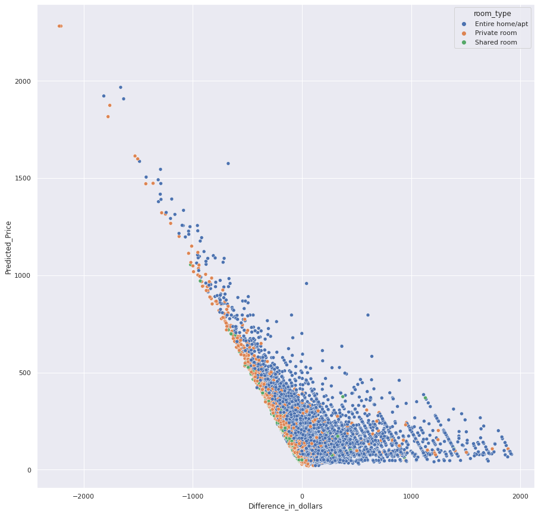

```python
sns.set(rc={"figure.figsize":(15,15)})
sns.scatterplot(
    data=AirBnBdf_new,
    x="Difference_in_dollars",
    y="Predicted_Price",
    hue=AirBnBdf_new["room_type"]
)
plt.show()
```

**Observations**

- The negative values in price difference denotes that the predicted price is more than the actual price.
- From the scattered plot we see that the `Private_room` accomodations have been predicted to be over priced than the actual price
- Though shared accommodations are very minimal, their prices seem to be way off too.

# Actionable Insights & Business Recommendations

*Insights for Hosts*

- The number of bedrooms, bathrooms and number of accomodations does not seem to be proportiante.
- Increase in the number of bedrooms and bathrooms for more accomodations will attract more customers.
- Rentals with Entire home/appartment is more widely used, most of them seem to be priced higher.
- Some of the shared accomodations are priced equally to entire home or appartment, there is a potential for customers to move to Entire home or apartment type, so price reasonably.

*Insights for Travellers*

- Instant booking options are available in most of the rentals to help planning the travel easier.

*Business recommendations for making profitable AirBnB business*

There appears to be a trend away from shared living arrangements like private rooms, more instant booking, and the increased use of Airbnb as a business venture rather than as an opportunity to personally connect with a guest, further reducing interactions between hosts and guests.